# Leslie-Caitlin-HOMEWORK-02

Caitlin Leslie

March 1, 2019

**Question 1** 1. Every Saturday, at the same time, a primatologist goes and sits in the forest in the morning and listens for titi monkey calls, counting the number of calls they hear in a 2 hour window from 5am to 7am. Based on previous knowledge, she believes that the mean number calls she will hear in that time is 15. Let X represent the appropriate Poisson random variable of the number of calls heard in each monitoring session.

1.a. What is the probability that she will hear more than 8 calls during any given session?

```r
1-ppois(q=8, lambda=15)
```

```
## [1] 0.9625535
```

1.b. What is the probability that she will hear no calls in a session?

```r
ppois(q=0, lambda=15)
```

```
## [1] 3.059023e-07
```

1.c. What is the probability that she will hear exactly 3 calls in a session?

```r
ppois(q=3, lambda = 15) - ppois(q=2, lambda = 15)
```

```
## [1] 0.0001720701
```

1.d. Plot the relevant Poisson mass function over the values in range 0 ≤ x ≤ 30.

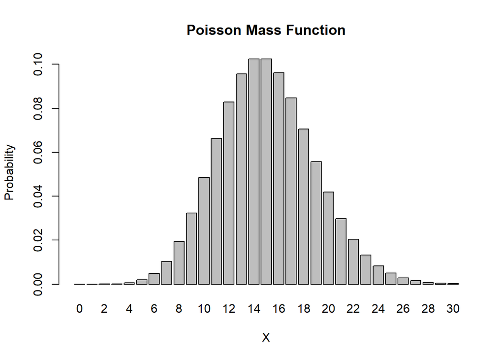

```r
x<-0:30
calls<-dpois(x, lambda=15)
barplot(calls, names.arg=x, xlab="X", ylab="Probability", main="Poisson Mass Function")
```

1.e. Simulate 104 results from this distribution (i.e., 2 years of Saturday monitoring sessions).

```r
sim<-rpois(n=104, lambda = 15)
sim
```

```
##   [1] 10  9 15 22 17 16 15 17 21 16 17 15 12 12 12 17 17 24 13 20 19 14 13
##  [24] 12 13 14 13 10  8 17 21 13 18 19 17 10 11 15 11 10 13 12 16 13 18 20
##  [47] 22 18 13 14 18 14 19 14 15 23 20 19  9 14 15 15 22 12 17  9 20 10 13
##  [70] 17 23 11 17 12 17 18 13 20 16 17 17 14 12 12 13 22  9 18 15 15  9 20
##  [93] 13 18 17 17 16 18 13 14 16 13 17 13
```

1.f. Plot the simulated results using hist() and use xlim() to set the horizontal limits to be from 0 to 30. How does your histogram compare to the shape of the probability mass function you plotted above?

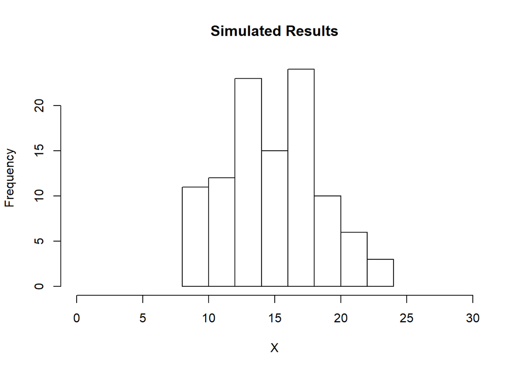

```r
hist(sim, xlab="X", xlim = range(0:30), main="Simulated Results")
```

The shapes are similar.

**Question 2** 2. Load in the dataset “zombies.csv” from my GitHub repository at https://github.com/difiore/ADA-2019. This data includes the first and last name and gender of the entire population of 1000 people who have survived the zombie apocalypse and are now ekeing out an existence somewhere on the East Coast, along with several other variables (height, weight, age, number of years of education, number of zombies they have killed, and college major.

```r
library(curl)
f <- f <- curl("https://raw.githubusercontent.com/difiore/ADA-2019/master/zombies.csv")
d <- read.csv(f, header = TRUE, sep = ",", stringsAsFactors = FALSE)
head(d)
```

```
##   id first_name last_name gender   height   weight zombies_killed
## 1  1      Sarah    Little Female 62.88951 132.0872              2
## 2  2       Mark    Duncan   Male 67.80277 146.3753              5
## 3  3    Brandon     Perez   Male 72.12908 152.9370              1
## 4  4      Roger   Coleman   Male 66.78484 129.7418              5
## 5  5      Tammy    Powell Female 64.71832 132.4265              4
## 6  6    Anthony     Green   Male 71.24326 152.5246              1
##   years_of_education                           major      age
## 1                  1                medicine/nursing 17.64275
## 2                  3 criminal justice administration 22.58951
## 3                  1                       education 21.91276
## 4                  6                  energy studies 18.19058
## 5                  3                       logistics 21.10399
## 6                  4                  energy studies 21.48355
```

2.a. Calculate the population mean and standard deviation for each quantitative random variable (height, weight, age, number of zombies killed, and years of education).

```r
sdz<-function(x) {sqrt((sum((x - mean(x))^2))/length(x))}

mean(d$height)
```

```
## [1] 67.6301
```

```r
sdz(d$height)
```

```
## [1] 4.30797
```

```r
mean(d$weight)
```

```
## [1] 143.9075
```

```r
sdz(d$weight)
```

```
## [1] 18.39186
```

```r
mean(d$age)
```

```
## [1] 20.04696
```

```r
sdz(d$age)
```

```
## [1] 2.963583
```

```r
mean(d$zombies_killed)
```

```
## [1] 2.992
```

```r
sdz(d$zombies_killed)
```

```
## [1] 1.747551
```

```r
mean(d$years_of_education)
```

```
## [1] 2.996
```

```r
sdz(d$years_of_education)
```

```
## [1] 1.675704
```

2.b. Use {ggplot} and make boxplots of each of these variable by gender.

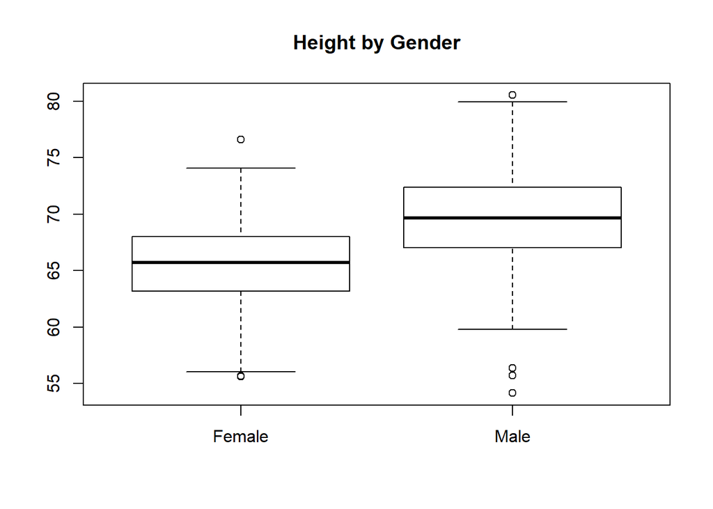

```r
library(ggplot2)
boxplot(d$height~gender,d, main="Height by Gender")
```

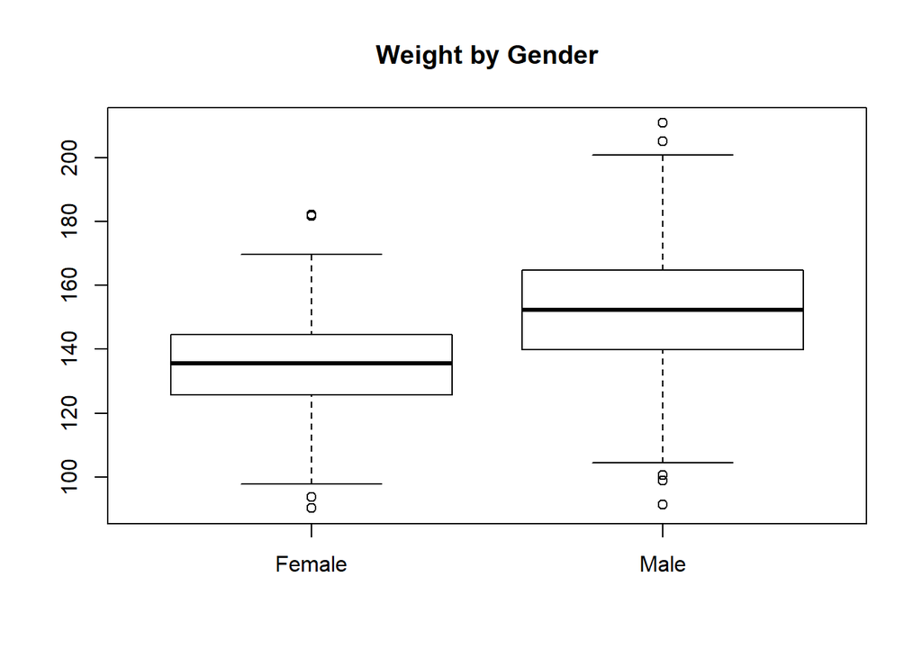

```r
boxplot(d$weight~gender,d, main="Weight by Gender")
```

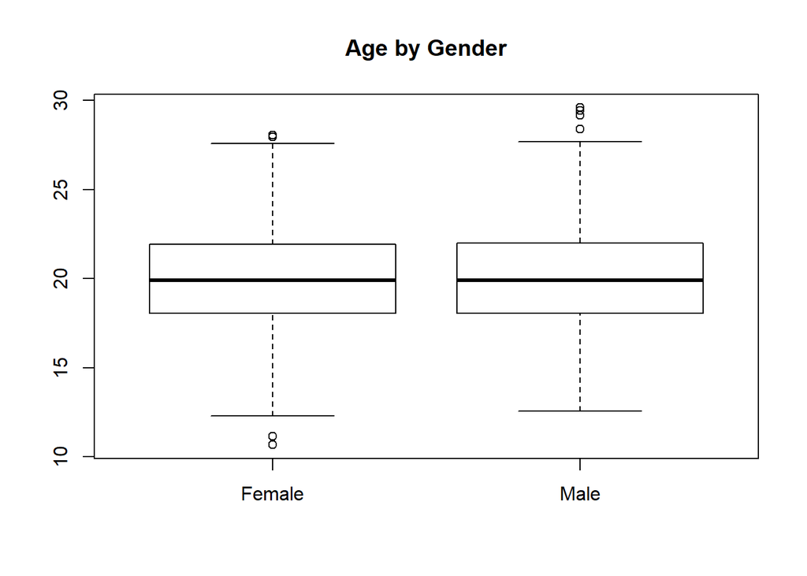

```r
boxplot(d$age~gender,d, main="Age by Gender")
```

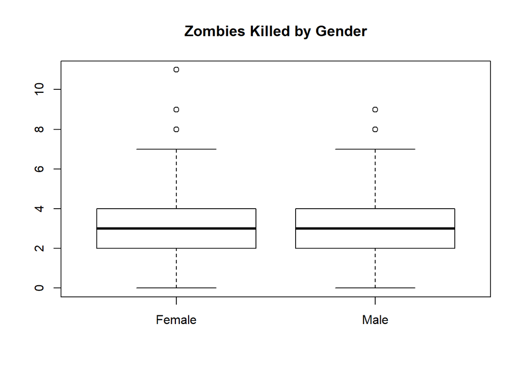

```r
boxplot(d$zombies_killed~gender,d, main="Zombies Killed by Gender")
```

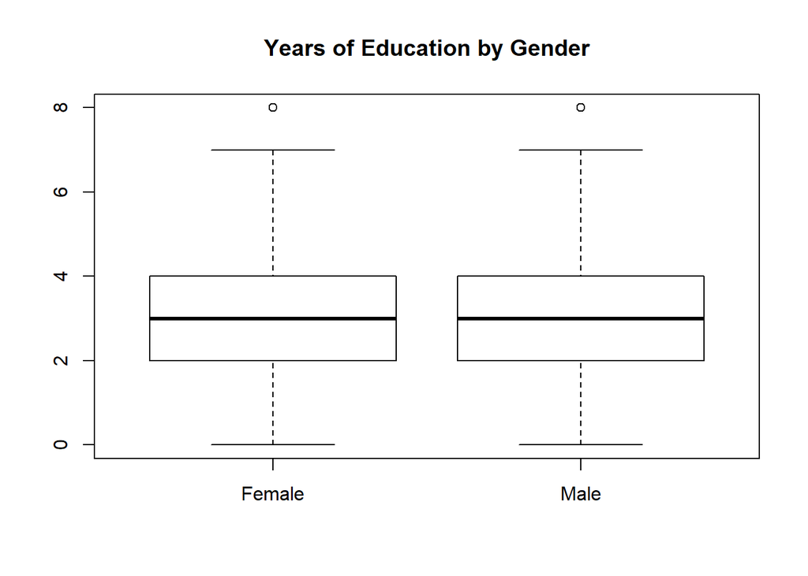

```r
boxplot(d$years_of_education~gender,d, main="Years of Education by Gender")
```

2.c. Use {ggplot} and make scatterplots of height and weight in relation to age. Do these variables seem to be related? In what way?

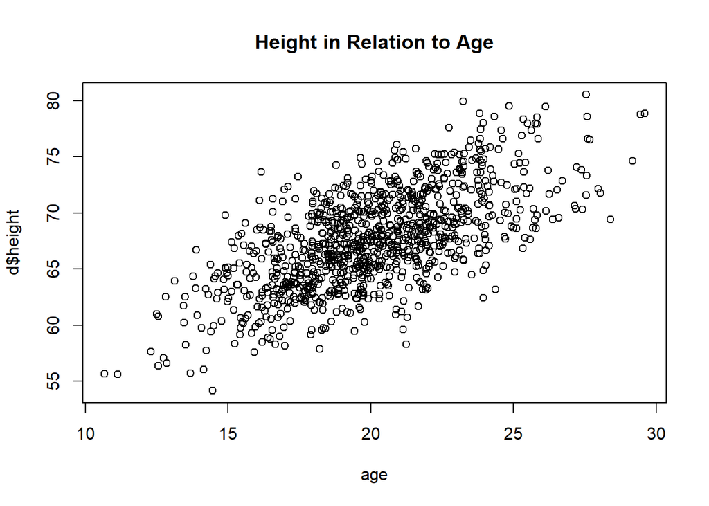

```r
plot(d$height~age,d, main="Height in Relation to Age")
```

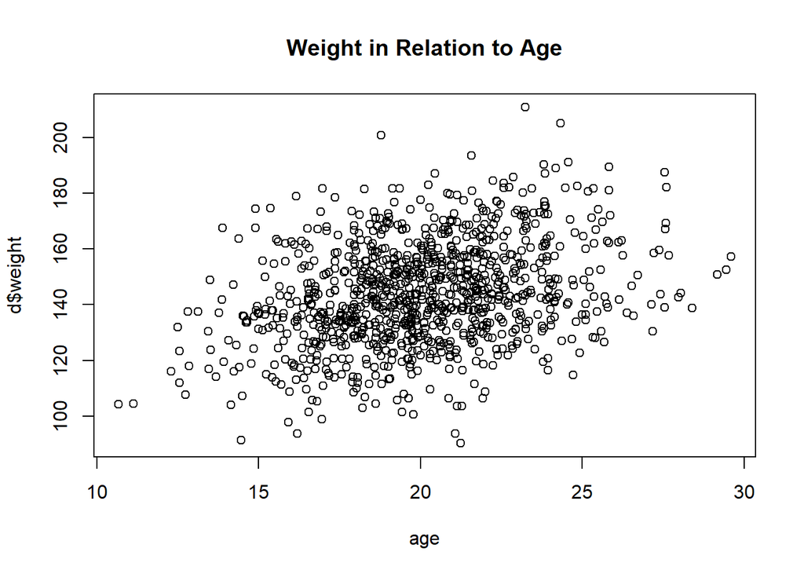

```r
plot(d$weight~age,d, main="Weight in Relation to Age")
```

They are both positively correlated with age.

2.d. Using histograms and Q-Q plots, check whether the quantitative variables seem to be drawn from a normal distribution. Which seem to be and which do not?

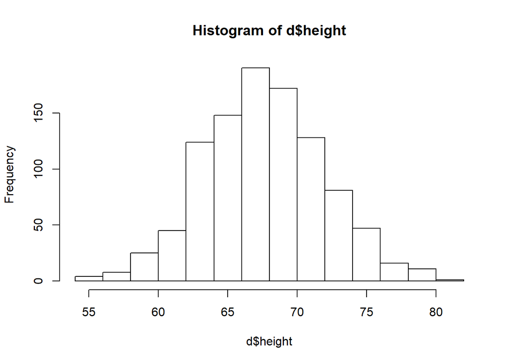

```r
hist(d$height)
```

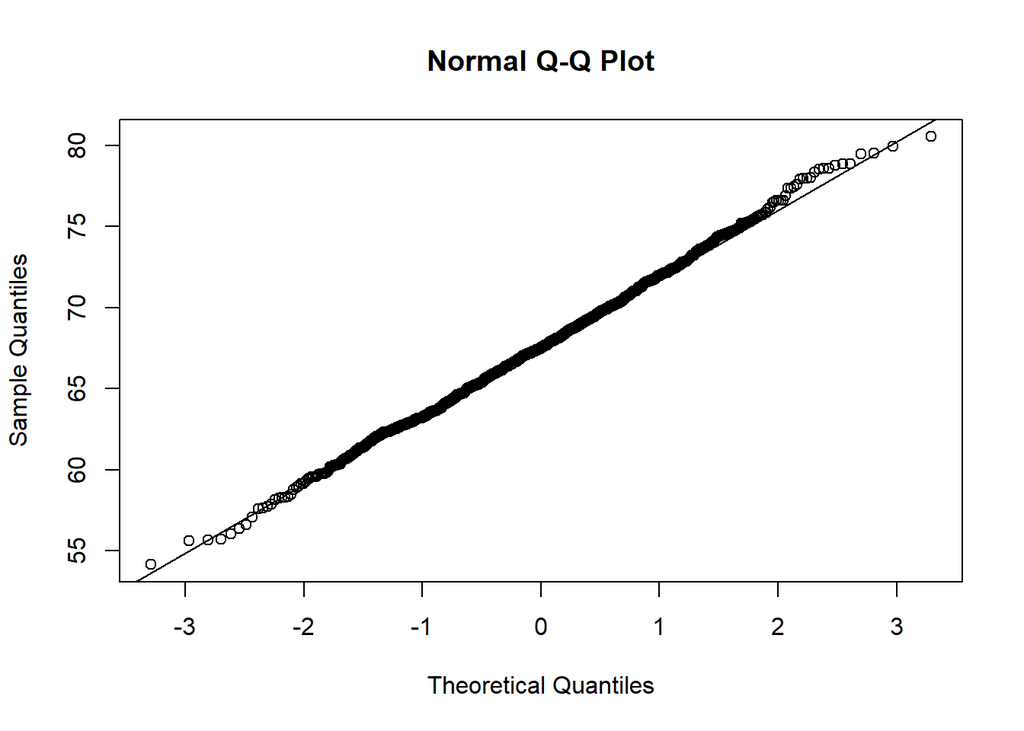

```r
qqnorm(d$height)
qqline(d$height)
```

Height seems to be from a normal distribution

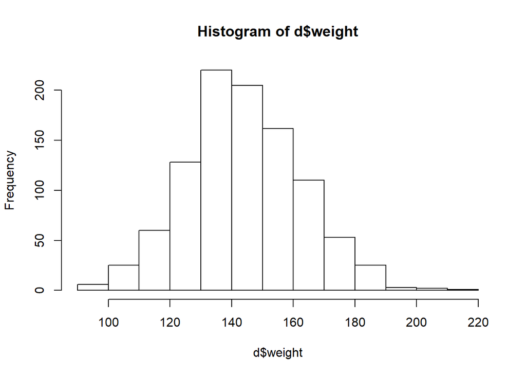

```r
hist(d$weight)
```

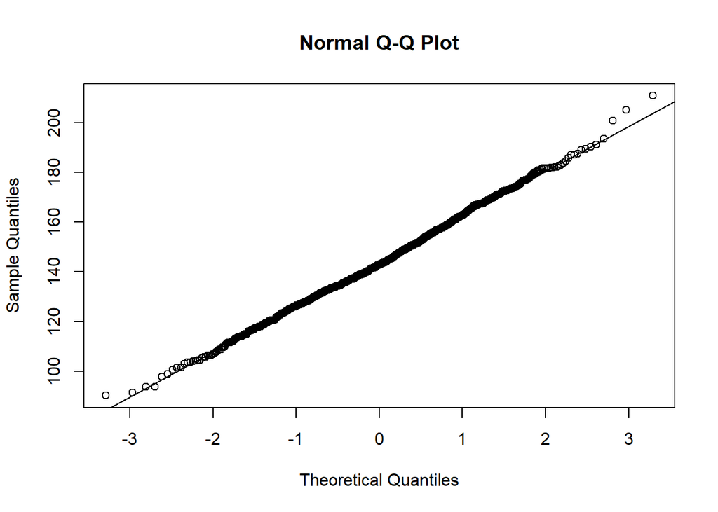

```r
qqnorm(d$weight)
qqline(d$weight)
```

Weight seems to be from a normal distribution

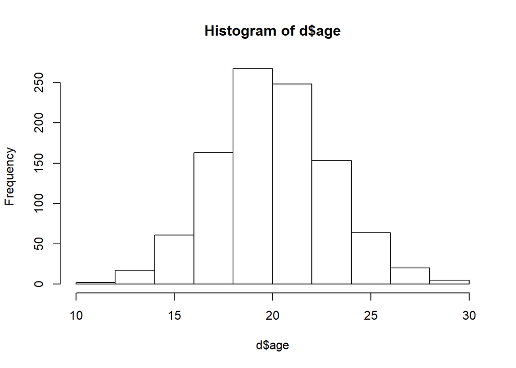

```r
hist(d$age)
```

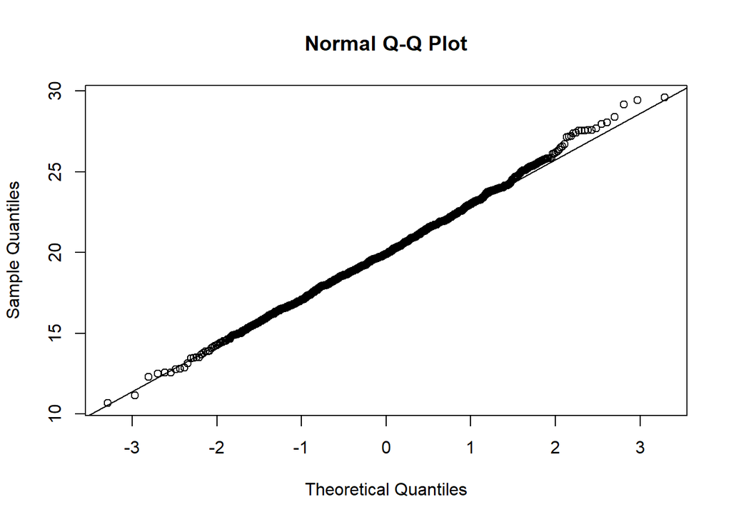

```r
qqnorm(d$age)
qqline(d$age)
```

Age seems to be from a normal distribution

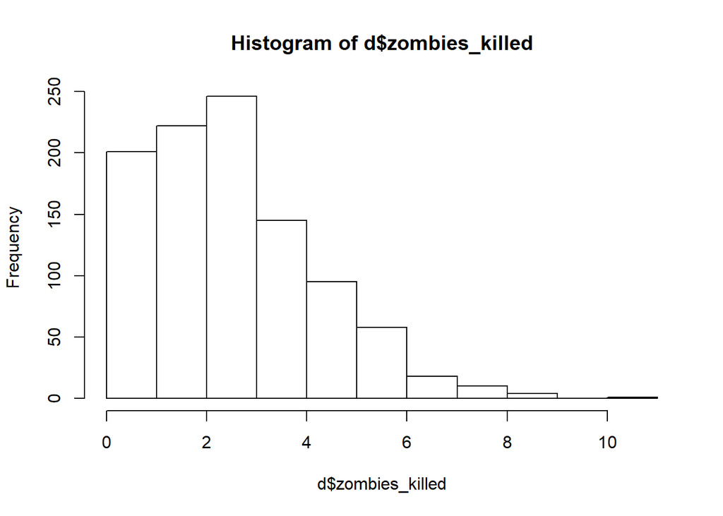

```r
hist(d$zombies_killed)
```

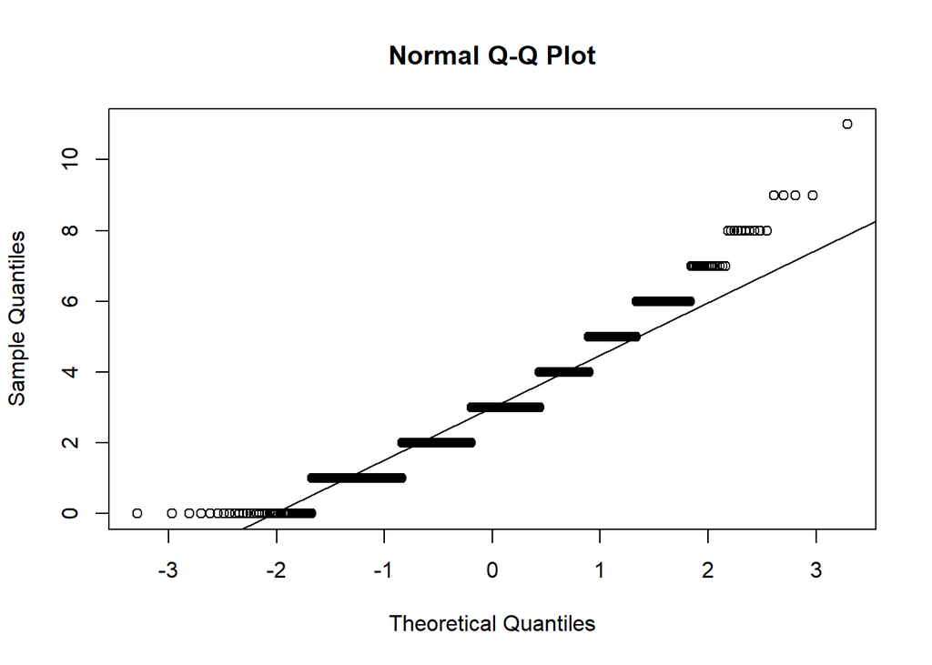

```r
qqnorm(d$zombies_killed)
qqline(d$zombies_killed)
```

Number of zombies killed does NOT seem to be from a normal distribution. It seems to be from a Poisson Distribution.

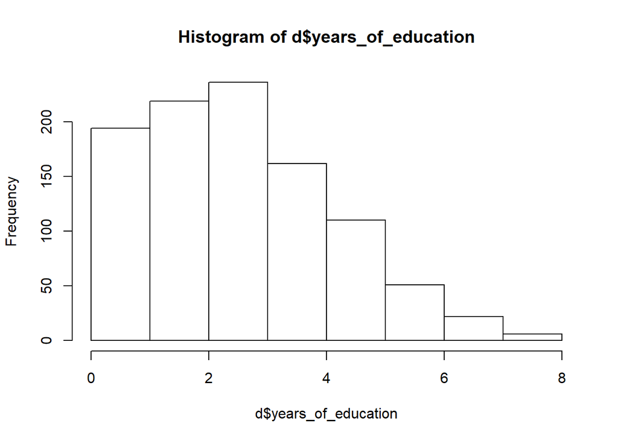

```r
hist(d$years_of_education)
```

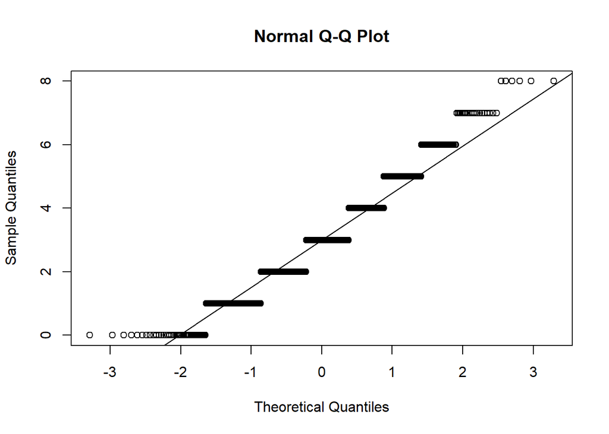

```r
qqnorm(d$years_of_education)
qqline(d$years_of_education)
```

Numbers of years of education does NOT Seem to be from a normal distribution. It seems to be from a Poisson Distribution.

2.e. Now use the sample() function to sample ONE subset of 30 zombies (without replacement) from this population and calculate the mean and sample standard deviation for each variable. Also estimate the standard error for each variable and construct the 95% confidence interval for each mean. Note that for the variables that are not drawn from the normal distribution, you will need to base your estimate of the CIs on some different distribution!

Sample one subset of 30 zombies without replacement

```r
library(manipulate)
zsubset<-d[sample(nrow(d), 30, replace=FALSE), ]
zsubset
```

```
##      id first_name last_name gender   height    weight zombies_killed
## 686 686      Ralph     Young   Male 67.44551 133.67453              3
## 689 689      Irene      Sims Female 65.77360 129.84006              7
## 489 489   Patricia    Peters Female 58.46348  93.75313              6
## 14   14     Louise      Hall Female 65.88747 131.53363              5
## 195 195   Jonathan   Ramirez   Male 68.74930 147.61040              2
## 614 614      Kelly  Gonzalez Female 62.92221 135.64142              2
## 313 313      Bobby      Rice   Male 63.80164 126.55416              5
## 465 465       Paul       Fox   Male 74.34293 174.25799              3
## 611 611      Maria   Andrews Female 68.41098 167.17393              2
## 755 755      Tammy  Anderson Female 66.13981 125.83486              4
## 505 505    Charles   Mendoza   Male 64.09470 123.52875              4
## 415 415     Bonnie    Jordan Female 63.58240 141.43774              2
## 889 889     Teresa     Ramos Female 66.27632 132.90110              1
## 46   46      Maria    Hudson Female 65.80217 139.41537              2
```

[output cut: 47 more lines]

```r
se <- function(x) {
    sd(x)/sqrt(length(x))
} #standard error function
```

Height

```r
h<-zsubset$height
mean(h)
```

```
## [1] 66.87672
```

```r
sd(h)
```

```
## [1] 4.174276
```

```r
se(h)
```

```
## [1] 0.7621151
```

```r
upper <- mean(h) + qnorm(0.975, mean = 0, sd = 1) * se(h)
lower <- mean(h) + qnorm(0.025, mean = 0, sd = 1) * se(h)
c(lower, upper) #95% confidence interval
```

```
## [1] 65.38300 68.37044
```

Weight

```r
w<-zsubset$weight
mean(w)
```

```
## [1] 140.0234
```

```r
sd(w)
```

```
## [1] 18.92896
```

```r
se(w)
```

```
## [1] 3.45594
```

```r
upper <- mean(w) + qnorm(0.975, mean = 0, sd = 1) * se(w)
lower <- mean(w) + qnorm(0.025, mean = 0, sd = 1) * se(w)
c(lower, upper) #95% confidence interval
```

```
## [1] 133.2499 146.7969
```

Age

```r
a<-zsubset$age
mean(a)
```

```
## [1] 19.45865
```

```r
sd(a)
```

```
## [1] 2.591274
```

```r
se(a)
```

```
## [1] 0.4730997
```

```r
upper <- mean(a) + qnorm(0.975, mean = 0, sd = 1) * se(a)
lower <- mean(a) + qnorm(0.025, mean = 0, sd = 1) * se(a)
c(lower, upper) #95% confidence interval
```

```
## [1] 18.53139 20.38591
```

Number of zombies killed

```r
z<-zsubset$zombies_killed
mean(z)
```

```
## [1] 2.966667
```

```r
sd(z)
```

```
## [1] 1.542129
```

```r
se(z)
```

```
## [1] 0.2815529
```

```r
upper <- mean(z) + qpois(0.975, lambda = mean(z)) * se(z)
lower <- mean(z) + qpois(0.025, lambda = mean(z)) * se(z)
c(lower, upper) #95% confidence interval
```

```
## [1] 2.966667 4.937537
```

Years of education

```r
y<-zsubset$years_of_education
mean(y)
```

```
## [1] 3
```

```r
sd(y)
```

```
## [1] 1.681543
```

```r
se(y)
```

```
## [1] 0.3070063
```

```r
upper <- mean(y) + qpois(0.975, lambda = mean(y)) * se(y)
lower <- mean(y) + qpois(0.025, lambda = mean(y)) * se(y)
c(lower, upper) #95% confidence interval
```

```
## [1] 3.000000 5.149044
```

2.f. Now draw 99 more random samples of 30 zombies out and calculate the mean for each of the these samples. Together with the first sample you drew out, you now have a set of 100 means for each variable (each based on 30 observations), which constitutes a sampling distribution for each variable. What are the means and standard deviations of the sampling distribution for each variable? How do the standard deviations compare to the standard errors estimated in [2.e.]? What do these sampling distributions look like? Are they normally distributed? What about for those variables that you concluded were not originally drawn from a normal distribution?

```r
k<-99
n<-30
s<-NULL
for (i in 1:k) {
    s[[i]] <- d[sample(nrow(d), 30, replace=FALSE), ]
}

s<-(c(s, list(zsubset)))
```

Height

```r
mh <- NULL
for (i in 1:k) {
    mh[i] <- mean(s[[i]]$height)
}
mh
```

```
##  [1] 67.84656 65.91820 67.27164 67.34562 67.54863 66.66217 67.24323
##  [8] 66.80843 66.35049 67.04033 68.07296 67.97393 69.08939 66.50245
## [15] 68.27477 68.79783 68.69477 67.58042 66.91861 67.54758 67.11948
## [22] 68.11806 66.93307 69.02102 68.13981 67.39195 67.15236 69.20724
## [29] 66.38549 66.85706 66.52229 67.60223 68.32765 67.89765 68.00378
## [36] 68.63646 68.91907 68.81203 66.52222 66.69369 67.51866 68.02114
## [43] 67.43718 68.18316 67.68494 66.61242 67.61679 67.35751 66.57002
## [50] 67.84724 68.20865 65.84179 67.19004 67.80071 68.03134 67.83624
## [57] 67.81252 68.69176 66.79391 67.77234 69.61711 67.12292 67.86257
## [64] 66.73817 67.69507 68.33804 67.94858 67.48299 67.33228 67.98946
## [71] 67.45835 66.43716 67.49633 68.09902 67.63521 66.84928 68.41032
## [78] 66.71245 67.85996 67.70444 67.58368 66.08945 67.65920 67.28180
## [85] 67.10383 68.15729 67.39055 67.75755 67.24766 66.60790 68.76222
## [92] 67.97647 68.31744 67.91734 66.88608 67.59204 68.32911 67.12230
## [99] 67.08971
```

```r
mean(mh)
```

```
## [1] 67.57818
```

```r
sd(mh)
```

```
## [1] 0.7574549
```

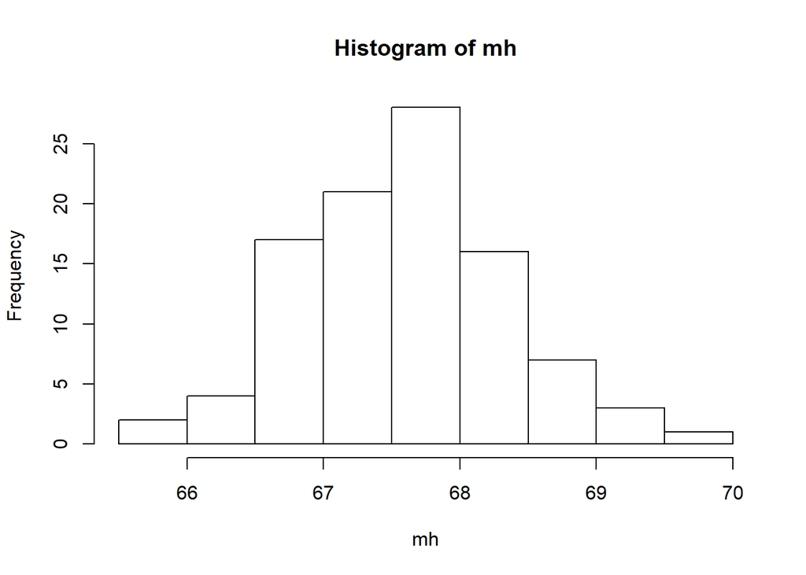

```r
hist(mh)
```

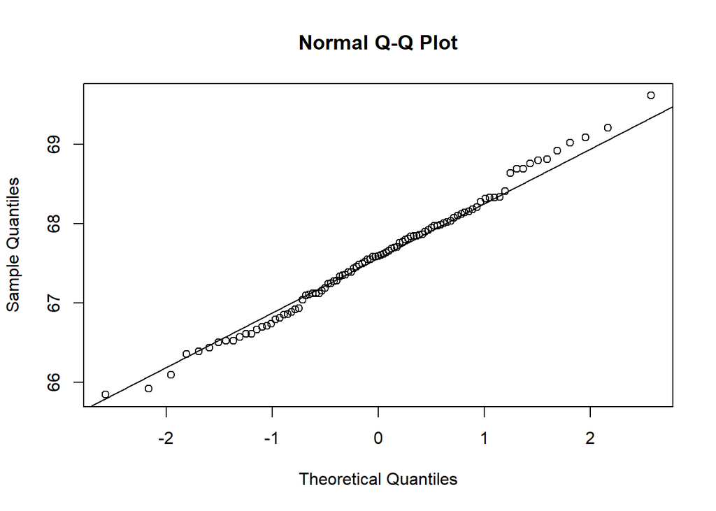

```r
qqnorm(mh)
qqline(mh)
```

Weight

```r
mw <- NULL
for (i in 1:k) {
    mw[i] <- mean(s[[i]]$weight)
}
mw
```

```
##  [1] 144.3463 136.7800 144.0152 143.2625 142.5824 139.6435 142.5328
##  [8] 140.8310 139.4302 141.2066 145.3083 146.1162 153.0712 138.9798
## [15] 147.7108 147.4370 148.7815 144.6073 138.0837 144.5710 142.4886
## [22] 142.3411 139.8730 151.2873 145.7861 144.9636 141.2176 149.8762
## [29] 138.2870 141.8704 140.0801 140.3098 146.9026 142.6757 145.4651
## [36] 145.3958 148.8356 147.4641 140.9289 139.1505 145.1372 147.0498
## [43] 142.3821 147.4939 145.7198 141.2491 143.0824 142.9053 139.2075
## [50] 146.3553 144.6833 137.3557 143.7530 148.6089 143.6415 144.9869
## [57] 145.3930 147.5935 137.3736 142.1131 150.7317 141.7087 145.6686
## [64] 142.6922 145.1272 144.3839 142.0232 142.9758 143.5012 145.3949
## [71] 146.1636 141.9012 141.7232 146.0740 146.3263 136.2607 149.5381
## [78] 141.2330 144.2023 144.5483 146.0209 138.8218 142.2310 142.6866
## [85] 144.1577 148.1631 140.9605 142.3709 142.5060 143.5104 147.3010
## [92] 145.8311 147.6877 144.0269 144.3374 143.6274 149.0719 143.2956
## [99] 141.8766
```

```r
mean(mw)
```

```
## [1] 143.8509
```

```r
sd(mw)
```

```
## [1] 3.333404
```

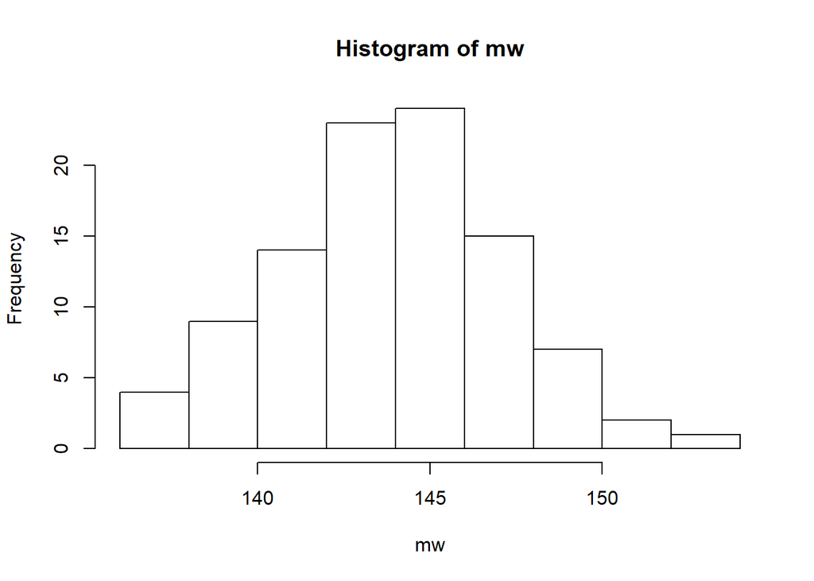

```r
hist(mw)
```

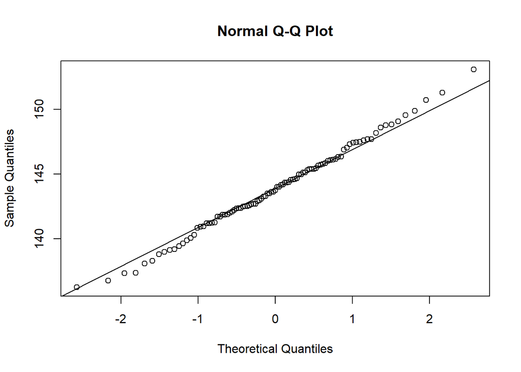

```r
qqnorm(mw)
qqline(mw)
```

Age

```r
ma <- NULL
for (i in 1:k) {
    ma[i] <- mean(s[[i]]$age)
}
ma
```

```
##  [1] 20.12148 19.30129 19.96249 19.51743 19.41443 19.77206 19.61031
##  [8] 19.38278 19.54900 19.84962 20.43661 19.43807 20.40264 19.60676
## [15] 20.18446 19.82669 20.37097 19.61313 19.92922 20.36342 20.65192
## [22] 21.07043 19.93641 20.51543 19.88471 20.22706 20.55506 20.86153
## [29] 19.86113 19.27845 19.91473 19.85002 20.31996 20.09426 20.02123
## [36] 20.97482 20.28698 20.14099 19.02640 19.42110 19.69526 19.66247
## [43] 19.80739 19.92088 19.75798 20.29760 20.52316 20.03063 20.14269
## [50] 19.74509 20.80887 19.06414 19.82504 18.97929 19.84204 20.02105
## [57] 19.87328 20.47226 20.30166 20.30332 20.35332 19.83471 20.00103
## [64] 19.70837 20.06470 21.04699 19.87519 20.13781 19.90102 20.40471
## [71] 19.56915 18.78356 20.26266 20.04604 19.72197 19.70603 20.70657
## [78] 20.04500 20.74813 20.00088 19.81220 19.31905 20.42039 19.66953
## [85] 19.07660 19.65874 20.45795 20.91845 19.44705 19.28704 20.27541
## [92] 20.00332 20.07526 19.76812 19.37935 20.40367 19.66747 19.93559
## [99] 19.65073
```

```r
mean(ma)
```

```
## [1] 19.96731
```

```r
sd(ma)
```

```
## [1] 0.4729961
```

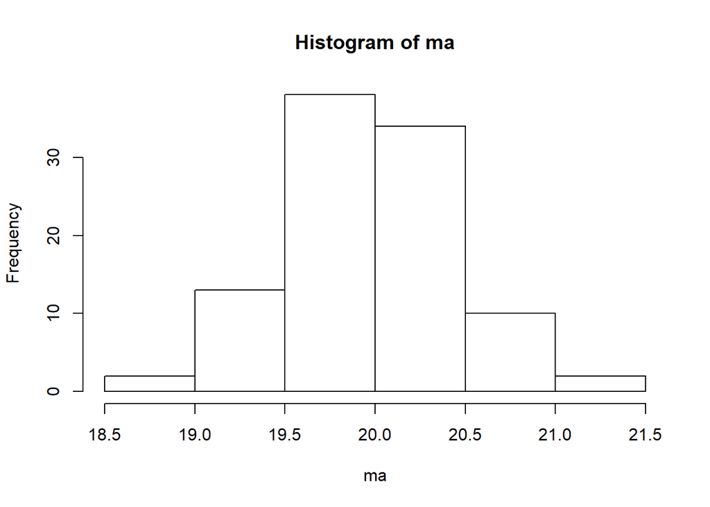

```r
hist(ma)
```

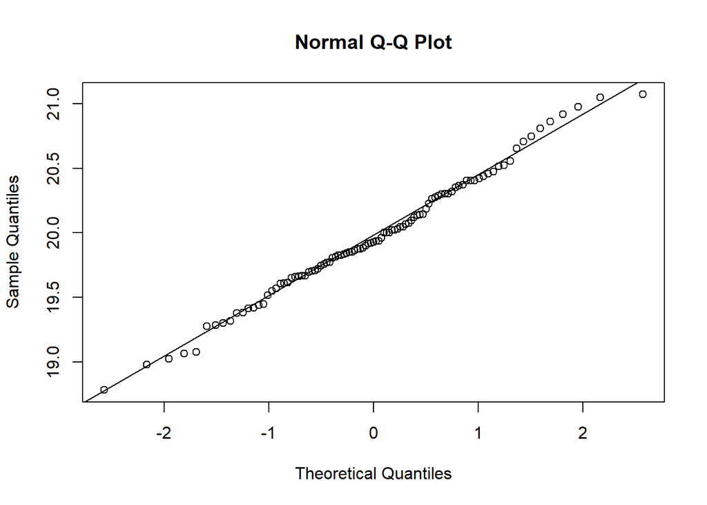

```r
qqnorm(ma)
qqline(ma)
```

Number of Zombies Killed

```r
mz <- NULL
for (i in 1:k) {
    mz[i] <- mean(s[[i]]$zombies_killed)
}
mz
```

```
##  [1] 3.033333 2.966667 3.066667 3.133333 3.800000 2.766667 2.633333
##  [8] 2.700000 2.633333 3.033333 3.000000 2.900000 3.366667 2.933333
## [15] 2.600000 2.766667 3.066667 2.566667 3.266667 3.200000 3.100000
## [22] 2.766667 2.833333 3.300000 2.966667 2.533333 2.666667 3.400000
## [29] 3.300000 2.900000 2.700000 2.933333 3.166667 3.166667 3.400000
## [36] 2.966667 3.233333 2.800000 2.866667 3.066667 2.800000 2.933333
## [43] 3.133333 3.333333 2.866667 2.533333 3.400000 2.866667 2.833333
## [50] 3.033333 3.233333 2.966667 3.133333 3.300000 2.766667 3.233333
## [57] 2.800000 3.133333 3.000000 2.600000 3.466667 2.866667 3.266667
## [64] 3.300000 2.833333 2.466667 2.433333 3.066667 3.233333 3.333333
## [71] 2.600000 3.133333 2.833333 3.000000 2.800000 2.766667 2.766667
## [78] 3.100000 3.433333 2.733333 2.933333 2.766667 2.933333 2.933333
## [85] 3.166667 2.866667 2.700000 3.433333 2.866667 2.833333 3.033333
## [92] 2.966667 3.300000 3.533333 3.133333 3.033333 3.033333 3.200000
## [99] 3.266667
```

```r
mean(mz)
```

```
## [1] 2.997643
```

```r
sd(mz)
```

```
## [1] 0.2637705
```

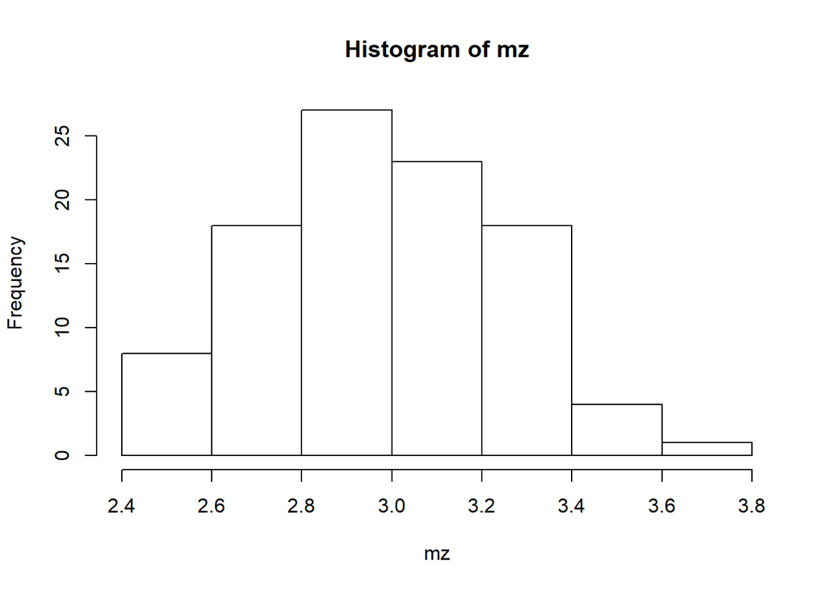

```r
hist(mz)
```

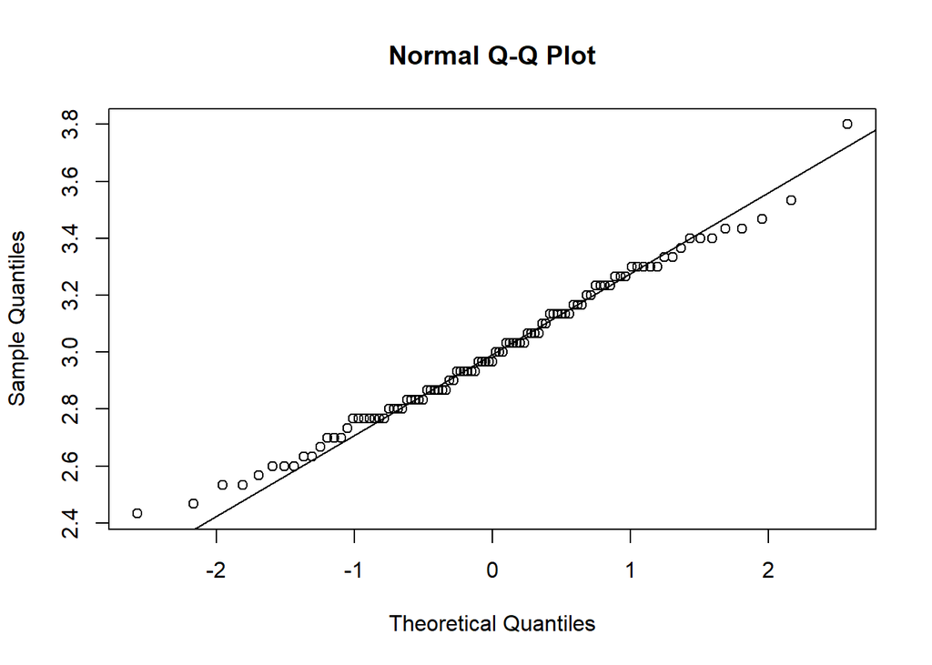

```r
qqnorm(mz)
qqline(mz)
```

Years of Education

```r
me <- NULL
for (i in 1:k) {
    me[i] <- mean(s[[i]]$years_of_education)
}
me
```

```
##  [1] 2.766667 2.600000 3.233333 3.533333 2.833333 2.700000 3.100000
##  [8] 2.066667 2.833333 3.066667 3.133333 3.300000 2.600000 3.366667
## [15] 2.566667 2.833333 2.700000 2.666667 2.866667 2.433333 2.733333
## [22] 2.666667 2.833333 2.933333 3.100000 3.500000 3.166667 3.233333
## [29] 3.166667 3.200000 2.933333 3.266667 2.500000 3.100000 3.000000
## [36] 3.266667 3.000000 2.766667 2.766667 2.866667 3.300000 2.733333
## [43] 2.800000 3.200000 3.466667 2.866667 3.266667 2.400000 2.933333
## [50] 2.700000 3.166667 3.133333 2.633333 2.900000 3.500000 3.266667
## [57] 2.966667 2.700000 3.100000 2.666667 2.900000 3.133333 3.000000
## [64] 2.566667 3.033333 2.933333 2.866667 2.866667 3.366667 2.633333
## [71] 2.900000 3.500000 3.066667 3.300000 2.900000 3.866667 3.100000
## [78] 2.633333 3.166667 2.833333 2.900000 3.000000 3.200000 3.100000
## [85] 3.000000 2.900000 3.300000 3.300000 3.133333 2.700000 3.133333
## [92] 3.100000 2.633333 2.833333 2.800000 2.666667 3.133333 3.233333
## [99] 2.700000
```

```r
mean(me)
```

```
## [1] 2.972054
```

```r
sd(me)
```

```
## [1] 0.2901523
```

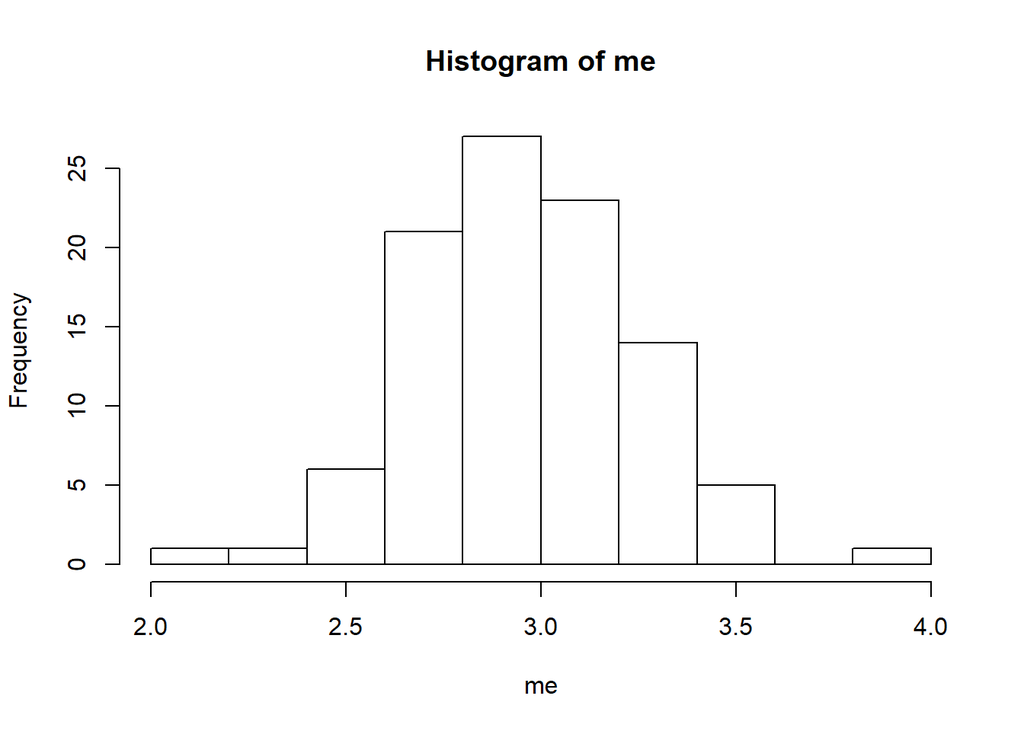

```r
hist(me)
```

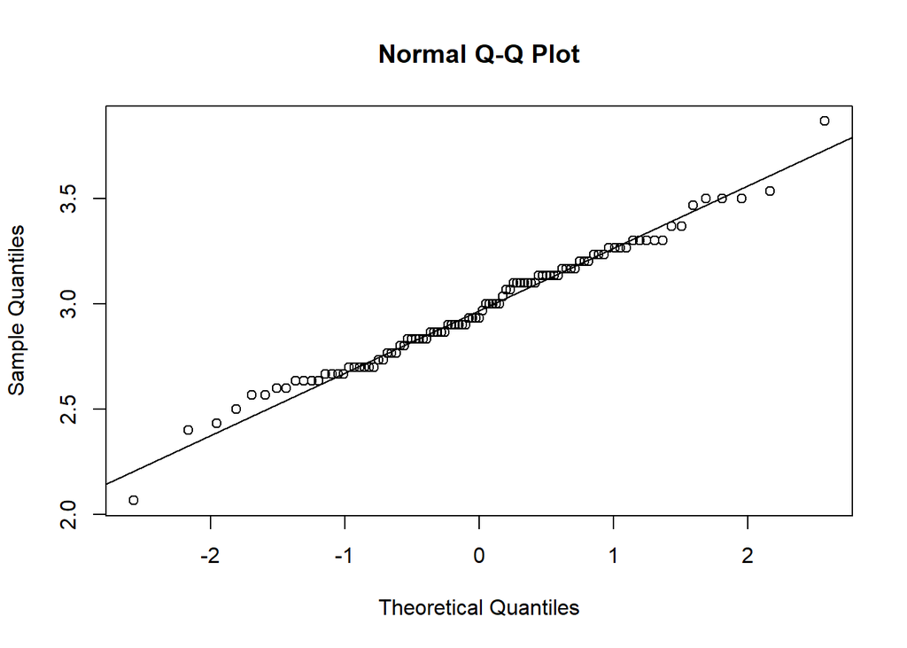

```r
qqnorm(me)
qqline(me)
```